# 3dasm_Lecture7 slides

[figure not shown]

## Data-driven Design and Analyses of Structures and Materials (3dasm)

## Lecture 7

### Miguel A. Bessa | M.A.Bessa@tudelft.nl | Associate Professor

## **OPTION 1**. Run this notebook **locally in your computer**:

1. Confirm that you have the 3dasm conda environment (see Lecture 1).
2. Go to the 3dasm_course folder in your computer and pull the last updates of the [repository](https://github.com/bessagroup/3dasm_course):

   ```
   git pull
   ```

3. Open command window and load jupyter notebook (it will open in your internet browser):

   ```
   conda activate 3dasm
   jupyter notebook
   ```

4. Open notebook of this Lecture.

## **OPTION 2**. Use **Google's Colab** (no installation required, but times out if idle):

1. go to https://colab.research.google.com
2. login
3. File > Open notebook
4. click on Github (no need to login or authorize anything)
5. paste the git link: https://github.com/bessagroup/3dasm_course
6. click search and then click on the notebook for this Lecture.

## Outline for today

- Understanding the Posterior Predictive Distribution (PPD)
  - Solution and discussion of Homework of Lecture 6

**Reading material**: This notebook

## Solution to Homework of Lecture 6

### Summary of the model

1. The **observation distribution**:

$$ p(y|z) = \mathcal{N}\left(y | \mu_{y|z}=w z+b, \sigma_{y|z}^2\right) = \frac{1}{C_{y|z}} \exp\left[ -\frac{1}{2\sigma_{y|z}^2}(y-\mu_{y|z})^2\right] $$

where $C_{y|z} = \sqrt{2\pi \sigma_{y|z}^2}$ is the **normalization constant** of the Gaussian pdf, and where $\mu_{y|z}=w z+b$, with $w$, $b$ and $\sigma_{y|z}^2$ being constants.

1. but now assuming a different **prior distribution**: $p(z) = \mathcal{N}\left(z| \overset{\scriptscriptstyle <}{\mu}_z=3, \overset{\scriptscriptstyle <}{\sigma}_z^2=2^2 \right)$

As in Lecture 6, we start by using Bayes' rule applied to data to determine the posterior:

$\require{color}$ $$ {\color{green}p(z|y=\mathcal{D}_y)} = \frac{ {\color{blue}p(y=\mathcal{D}_y|z)}{\color{red}p(z)} } {p(y=\mathcal{D}_y)} $$

The likelihood is the same as in Lecture 6:

$$ {\color{blue}p(y=\mathcal{D}_y | z)} = \frac{1}{|w|^N} \cdot C \cdot \frac{1}{\sqrt{2\pi \sigma^2}} \exp\left[ -\frac{1}{2\sigma^2}(z-\mu)^2\right] $$

where $\mu = \frac{w^2\sigma^2}{\sigma_{y|z}^2} \sum_{i=1}^N \mu_i = \frac{\sum_{i=1}^N y_i}{w N}-\frac{b}{w}$

$\sigma^2 = \frac{\sigma_{y|z}^2}{w^2 N}$, and

$C = \frac{1}{2\pi^{(N-1)/2}} \sqrt{\frac{\sigma^2}{\left( \frac{\sigma_{y|z}^2}{w^2}\right)^N}} $

But now the marginal likelihood is different from Lecture 6 because we have a different prior:

$$ p(y=\mathcal{D}_y) = \frac{C\cdot C_M}{|w|^N} $$

where $C_M = \frac{1}{\sqrt{2\pi\left(\sigma^2+\overset{\scriptscriptstyle <}{\sigma}_z^2\right)}} \exp\left[-\frac{1}{2\left(\sigma^2+\overset{\scriptscriptstyle <}{\sigma}_z^2\right)}\left(\mu - \overset{\scriptscriptstyle <}{\mu}_z\right)^2 \right]$.

(Algebra to get this result is in the notes below.)

Therefore, the posterior will also be different:

$$\require{color}\begin{align} {\color{green}p(z|y=\mathcal{D}_y)} &= \frac{ p(y=\mathcal{D}_y|z)p(z) } {p(y=\mathcal{D}_y)} \\ &= \frac{|w|^N}{C\cdot C_M} \cdot \frac{1}{|w|^N} C \cdot \mathcal{N}(z|\mu,\sigma^2) \cdot \mathcal{N}\left(z| \overset{\scriptscriptstyle <}{\mu}_z, \overset{\scriptscriptstyle <}{\sigma}_z^2\right) \\ &= \mathcal{N}\left(z| \overset{\scriptscriptstyle >}{\mu}_z, \overset{\scriptscriptstyle >}{\sigma}_z^2\right) \end{align} $$

where $\overset{\scriptscriptstyle >}{\mu}_z = \frac{1}{\frac{1}{\sigma^2} + \frac{1}{\overset{\scriptscriptstyle <}{\sigma}_z^2}} \left( \frac{\mu}{\sigma^2} + \frac{\overset{\scriptscriptstyle <}{\mu}_z}{\overset{\scriptscriptstyle <}{\sigma}_z^2}\right)$

and $\overset{\scriptscriptstyle >}{\sigma}_z^2 = \frac{1}{\frac{1}{\sigma^2} + \frac{1}{\overset{\scriptscriptstyle <}{\sigma}_z^2}}$

are the parameters of the posterior distribution, symbolized by the superscript $\overset{\scriptscriptstyle >}{(\cdot)}$.

Reflection on the differences between the posterior we obtain for the two different priors we considered.

- When using the noninformative Uniform prior $p(z) = \frac{1}{C_z}$ (Lecture 6):

$$\require{color}\begin{align} {\color{green}p(z|y=\mathcal{D}_y)} &= \mathcal{N}(z|\mu, \sigma^2) \end{align} $$

- When using a Gaussian prior $p(z) = \mathcal{N}\left(z| \overset{\scriptscriptstyle <}{\mu}_z, \overset{\scriptscriptstyle <}{\sigma}_z^2\right)$ (this Lecture):

$$\require{color}\begin{align} {\color{green}p(z|y=\mathcal{D}_y)} &= \mathcal{N}\left(z| \overset{\scriptscriptstyle >}{\mu}_z, \overset{\scriptscriptstyle >}{\sigma}_z^2\right) = \mathcal{N}\left(z\left|\frac{1}{\frac{1}{\sigma^2} + \frac{1}{\overset{\scriptscriptstyle <}{\sigma}_z^2}} \left( \frac{\mu}{\sigma^2} + \frac{\overset{\scriptscriptstyle <}{\mu}_z}{\overset{\scriptscriptstyle <}{\sigma}_z^2}\right), \frac{1}{\frac{1}{\sigma^2} + \frac{1}{\overset{\scriptscriptstyle <}{\sigma}_z^2}}\right.\right) \end{align} $$

The posterior is still a Gaussian but its mean and variance have been updated by the influence of the prior!

Finally, the goal of calculating the posterior is to use it to determine the Posterior Predictive Distribution (PPD) :

$$\require{color} {\color{orange}p(y|\mathcal{D}_y)} = \int \underbrace{p(y|z)}_{\text{observation}\\ \text{distribution}} \overbrace{p(z|y=\mathcal{D}_y)}^{\text{posterior}} dz $$

Considering the terms we found before, we get:

$$\begin{align} p(y|\mathcal{D}_y) &= \int \underbrace{\frac{1}{|w|}\frac{1}{\sqrt{2\pi \left(\frac{\sigma_{y|z}}{w}\right)^2}} \exp\left\{ -\frac{1}{2\left(\frac{\sigma_{y|z}}{w}\right)^2}\left[z-\left(\frac{y-b}{w}\right)\right]^2\right\} }_{\text{observation}\\ \text{distribution}} \overbrace{\mathcal{N}\left(z| \overset{\scriptscriptstyle >}{\mu}_z, \overset{\scriptscriptstyle >}{\sigma}_z^2\right)}^{\text{posterior}} dz \end{align} $$

The calculation of this integral is similar to what we did in Lecture 6! The difference is that the posterior has a different mean and variance (indicated with the superscript) that originated from the choice of different prior!

So, we can fast forward to the result we obtained before! We just need to replace the symbols $\mu_z$ by $\overset{\scriptscriptstyle >}{\mu}_z$, and $\sigma_z^2$ for $\overset{\scriptscriptstyle >}{\sigma}_z^2$:

$$\require{color} {\color{orange}p(y|\mathcal{D}_y)} = \frac{\tilde{C}}{|w|} $$

where

$$\tilde{C} = \frac{1}{\sqrt{2\pi \left( \overset{\scriptscriptstyle >}{\sigma}_z^2 + \frac{\sigma_{y|z}^2}{w^2} \right)}}\exp\left[ - \frac{\left(\overset{\scriptscriptstyle >}{\mu}_z - \frac{y-b}{w}\right)^2}{2\left( \overset{\scriptscriptstyle >}{\sigma}_z^2+\frac{\sigma_{y|z}^2}{w^2}\right)}\right]$$

is the same constant as $C^*$ in Lecture 6, but replacing $\mu_z$ by $\overset{\scriptscriptstyle >}{\mu}_z$, and $\sigma_z^2$ for $\overset{\scriptscriptstyle >}{\sigma}_z^2$.

After a bit of algebra, we get to the following expression for the PPD:

$$\require{color} \begin{align} {\color{orange}p(y|\mathcal{D}_y)} &= \frac{1}{\sqrt{2\pi \left( \sigma_{y|z}^2 + w^2\overset{\scriptscriptstyle >}{\sigma}_z^2\right)}}\exp\left\{ - \frac{1}{2\left( \sigma_{y|z}^2 + w^2\overset{\scriptscriptstyle >}{\sigma}_z^2\right)}\left[y-\left(w\overset{\scriptscriptstyle >}{\mu}_z+b\right)\right]^2\right\} \\ &= \mathcal{N}\left(y \left| w\overset{\scriptscriptstyle >}{\mu}_z+b , \sigma_{y|z}^2 + w^2\overset{\scriptscriptstyle >}{\sigma}_z^2 \right.\right) \\ \end{align} $$

where all of the terms have been defined before (for convenience, see them in the next cell as notes).

In order to see the explicit dependence on the observed data $\mathcal{D}_y$, we can also rewrite the PPD as:

$$\require{color} {\color{orange}p(y|\mathcal{D}_y)} = \mathcal{N}\left(y \left| \mu^*, \sigma^* \right.\right) $$

where

$ \mu^* = \frac{1}{1+\frac{x^2\sigma_{z_2}^2}{N \overset{\scriptscriptstyle <}{\sigma}_z^2}}\left[\frac{\sum_{i=1}^N y_i}{N} + \frac{x^2\sigma_{z_2}^2}{N \overset{\scriptscriptstyle <}{\sigma}_z^2}\left( w \overset{\scriptscriptstyle <}{\mu}_z + b\right) \right] $

$ \left(\sigma^*\right)^2 = \sigma_{y|z}^2 + \frac{w^2\sigma^2\overset{\scriptscriptstyle <}{\sigma}_z^2}{\overset{\scriptscriptstyle <}{\sigma}_z^2+\sigma^2} = \sigma_{y|z}^2 + \frac{w^2 x^2 \sigma_{z_2}^2 \overset{\scriptscriptstyle <}{\sigma}_z^2}{N \overset{\scriptscriptstyle <}{\sigma}_z^2 + x^2 \sigma_{z_2}^2} $

- What happens when $N \rightarrow \infty$ ?

When $N \rightarrow \infty$ the mean and variance of the PPD become:

$$ \mu^* = \frac{\sum_{i=1}^N y_i}{N} \equiv \text{Empirical mean} $$$$ \left(\sigma^*\right)^2 = \sigma_{y|z}^2 = (x^2 \sigma_{z_2})^2 \equiv \text{Variance caused only from } z_2 \text{ rv} $$

So, in this limit of the PPD is simply:

$$\require{color} {\color{orange}p(y|\mathcal{D}_y)} = \mathcal{N}\left(y \left| \frac{\sum_{i=1}^N y_i}{N}, \sigma_{y|z}^2 \right.\right) \quad \text{when } N\rightarrow \infty $$

- This means that in the limit of $N \rightarrow \infty$ we have exactly the same result obtained when we used the noninformative Uniform prior! Were you expecting this? Let's debate!

```
Ground truth              : mean[y] = 675    & std[y] = 67.6
Empirical values (purple) : mean[y] = 605.26 & std[y] = 47.74
PPD with Uniform Prior (orange): mean[y] = 605.26 & std[y] = 68.89
PPD with Gaussian Prior (blue) : mean[y] = 617.23 & std[y] = 68.13
```

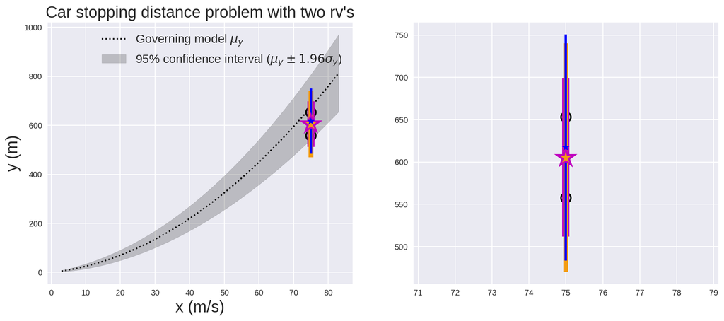

```python
HW_Lec6_PPD_comparison(N_samples=2) # Plot data and the two PPD's considering different priors
```

### See you next class

Have fun!